# Predict Bike Sharing Demand with AutoGluon Template

## Project: Predict Bike Sharing Demand with AutoGluon

This notebook is a template with each step that you need to complete for the project.

Please fill in your code where there are explicit `?` markers in the notebook. You are welcome to add more cells and code as you see fit.

Once you have completed all the code implementations, please export your notebook as a HTML file so the reviews can view your code. Make sure you have all outputs correctly outputted.

`File-> Export Notebook As... -> Export Notebook as HTML`

There is a writeup to complete as well after all code implememtation is done. Please answer all questions and attach the necessary tables and charts. You can complete the writeup in either markdown or PDF.

Completing the code template and writeup template will cover all of the rubric points for this project.

The rubric contains "Stand Out Suggestions" for enhancing the project beyond the minimum requirements. The stand out suggestions are optional. If you decide to pursue the "stand out suggestions", you can include the code in this notebook and also discuss the results in the writeup file.

## Step 1: Create an account with Kaggle

### Create Kaggle Account and download API key

Below is example of steps to get the API username and key. Each student will have their own username and key.

1. Open account settings.

2. Scroll down to API and click Create New API Token.

3. Open up `kaggle.json` and use the username and key.


## Step 2: Download the Kaggle dataset using the kaggle python library

### Open up Sagemaker Studio and use starter template

1. Notebook should be using a `ml.t3.medium` instance (2 vCPU + 4 GiB)
2. Notebook should be using kernal: `Python 3 (MXNet 1.8 Python 3.7 CPU Optimized)`

### Install packages

```python
!pip install -U pip
!pip install -U setuptools wheel
!pip install -U "mxnet<2.0.0" bokeh==2.0.1
!pip install autogluon --no-cache-dir
# Without --no-cache-dir, smaller aws instances may have trouble installing
```

[output not shown]

[output cut: 56 more lines]

[output not shown]

### Setup Kaggle API Key

```python
# create the .kaggle directory and an empty kaggle.json file
!mkdir -p /root/.kaggle
!touch /root/.kaggle/kaggle.json
!chmod 600 /root/.kaggle/kaggle.json
```

```python
# Fill in your user name and key from creating the kaggle account and API token file
import json
kaggle_username = "archieprad"
kaggle_key = "599f2526cff3e0d7a386883445813322"

# Save API token the kaggle.json file
with open("/root/.kaggle/kaggle.json", "w") as f:
    f.write(json.dumps({"username": kaggle_username, "key": kaggle_key}))
```

### Download and explore dataset

### Go to the bike sharing demand competition and agree to the terms

```python
# Download the dataset, it will be in a .zip file so you'll need to unzip it as well.
!kaggle competitions download -c bike-sharing-demand
# If you already downloaded it you can use the -o command to overwrite the file
!unzip -o bike-sharing-demand.zip
```

```
Downloading bike-sharing-demand.zip to /root/cd0385-project-starter/project
Archive:  bike-sharing-demand.zip
  inflating: sampleSubmission.csv
  inflating: test.csv
  inflating: train.csv
```

```python
import pandas as pd
from autogluon.tabular import TabularPredictor
```

```python
# Create the train dataset in pandas by reading the csv
# Set the parsing of the datetime column so you can use some of the `dt` features in pandas later
train = pd.read_csv('train.csv', parse_dates=['datetime'])
train.head()
```

|  | datetime | season | holiday | workingday | weather | temp | atemp | humidity | windspeed | casual | registered | count |
| --- | --- | --- | --- | --- | --- | --- | --- | --- | --- | --- | --- | --- |
| 0 | 2011-01-01 00:00:00 | 1 | 0 | 0 | 1 | 9.84 | 14.395 | 81 | 0.0 | 3 | 13 | 16 |
| 1 | 2011-01-01 01:00:00 | 1 | 0 | 0 | 1 | 9.02 | 13.635 | 80 | 0.0 | 8 | 32 | 40 |
| 2 | 2011-01-01 02:00:00 | 1 | 0 | 0 | 1 | 9.02 | 13.635 | 80 | 0.0 | 5 | 27 | 32 |
| 3 | 2011-01-01 03:00:00 | 1 | 0 | 0 | 1 | 9.84 | 14.395 | 75 | 0.0 | 3 | 10 | 13 |
| 4 | 2011-01-01 04:00:00 | 1 | 0 | 0 | 1 | 9.84 | 14.395 | 75 | 0.0 | 0 | 1 | 1 |

```python
# Simple output of the train dataset to view some of the min/max/varition of the dataset features.
train.describe()
```

|  | season | holiday | workingday | weather | temp | atemp | humidity | windspeed | casual | registered | count |
| --- | --- | --- | --- | --- | --- | --- | --- | --- | --- | --- | --- |
| count | 10886.000000 | 10886.000000 | 10886.000000 | 10886.000000 | 10886.00000 | 10886.000000 | 10886.000000 | 10886.000000 | 10886.000000 | 10886.000000 | 10886.000000 |
| mean | 2.506614 | 0.028569 | 0.680875 | 1.418427 | 20.23086 | 23.655084 | 61.886460 | 12.799395 | 36.021955 | 155.552177 | 191.574132 |
| std | 1.116174 | 0.166599 | 0.466159 | 0.633839 | 7.79159 | 8.474601 | 19.245033 | 8.164537 | 49.960477 | 151.039033 | 181.144454 |
| min | 1.000000 | 0.000000 | 0.000000 | 1.000000 | 0.82000 | 0.760000 | 0.000000 | 0.000000 | 0.000000 | 0.000000 | 1.000000 |
| 25% | 2.000000 | 0.000000 | 0.000000 | 1.000000 | 13.94000 | 16.665000 | 47.000000 | 7.001500 | 4.000000 | 36.000000 | 42.000000 |
| 50% | 3.000000 | 0.000000 | 1.000000 | 1.000000 | 20.50000 | 24.240000 | 62.000000 | 12.998000 | 17.000000 | 118.000000 | 145.000000 |
| 75% | 4.000000 | 0.000000 | 1.000000 | 2.000000 | 26.24000 | 31.060000 | 77.000000 | 16.997900 | 49.000000 | 222.000000 | 284.000000 |
| max | 4.000000 | 1.000000 | 1.000000 | 4.000000 | 41.00000 | 45.455000 | 100.000000 | 56.996900 | 367.000000 | 886.000000 | 977.000000 |

```python
# Create the test pandas dataframe in pandas by reading the csv, remember to parse the datetime!
test = pd.read_csv('test.csv', parse_dates=['datetime'])
test.head()
```

|  | datetime | season | holiday | workingday | weather | temp | atemp | humidity | windspeed |
| --- | --- | --- | --- | --- | --- | --- | --- | --- | --- |
| 0 | 2011-01-20 00:00:00 | 1 | 0 | 1 | 1 | 10.66 | 11.365 | 56 | 26.0027 |
| 1 | 2011-01-20 01:00:00 | 1 | 0 | 1 | 1 | 10.66 | 13.635 | 56 | 0.0000 |
| 2 | 2011-01-20 02:00:00 | 1 | 0 | 1 | 1 | 10.66 | 13.635 | 56 | 0.0000 |
| 3 | 2011-01-20 03:00:00 | 1 | 0 | 1 | 1 | 10.66 | 12.880 | 56 | 11.0014 |
| 4 | 2011-01-20 04:00:00 | 1 | 0 | 1 | 1 | 10.66 | 12.880 | 56 | 11.0014 |

```python
# Same thing as train and test dataset
submission = pd.read_csv('sampleSubmission.csv', parse_dates=['datetime'])
submission.head()
```

|  | datetime | count |
| --- | --- | --- |
| 0 | 2011-01-20 00:00:00 | 0 |
| 1 | 2011-01-20 01:00:00 | 0 |
| 2 | 2011-01-20 02:00:00 | 0 |
| 3 | 2011-01-20 03:00:00 | 0 |
| 4 | 2011-01-20 04:00:00 | 0 |

## Step 3: Train a model using AutoGluon’s Tabular Prediction

Requirements:

- We are prediting `count`, so it is the label we are setting.
- Ignore `casual` and `registered` columns as they are also not present in the test dataset.
- Use the `root_mean_squared_error` as the metric to use for evaluation.
- Set a time limit of 10 minutes (600 seconds).
- Use the preset `best_quality` to focus on creating the best model.

```python
predictor = TabularPredictor(label="count", eval_metric="root_mean_squared_error").fit(
                                                train_data=train.drop(columns=['casual','registered']),
                                                time_limit= 600,
                                                presets="best_quality")
```

```
No path specified. Models will be saved in: "AutogluonModels/ag-20221229_033301/"
Presets specified: ['best_quality']
Beginning AutoGluon training ... Time limit = 600s
AutoGluon will save models to "AutogluonModels/ag-20221229_033301/"
AutoGluon Version:  0.3.1
Train Data Rows:    10886
Train Data Columns: 9
Preprocessing data ...
AutoGluon infers your prediction problem is: 'regression' (because dtype of label-column == int and many unique label-values observed).
	Label info (max, min, mean, stddev): (977, 1, 191.57413, 181.14445)
	If 'regression' is not the correct problem_type, please manually specify the problem_type argument in fit() (You may specify problem_type as one of: ['binary', 'multiclass', 'regression'])
Using Feature Generators to preprocess the data ...
Fitting AutoMLPipelineFeatureGenerator...
	Available Memory:                    2258.84 MB
	Train Data (Original)  Memory Usage: 0.78 MB (0.0% of available memory)
	Inferring data type of each feature based on column values. Set feature_metadata_in to manually specify special dtypes of the features.
	Stage 1 Generators:
		Fitting AsTypeFeatureGenerator...
			Note: Converting 2 features to boolean dtype as they only contain 2 unique values.
	Stage 2 Generators:
		Fitting FillNaFeatureGenerator...
	Stage 3 Generators:
		Fitting IdentityFeatureGenerator...
		Fitting DatetimeFeatureGenerator...
	Stage 4 Generators:
		Fitting DropUniqueFeatureGenerator...
	Types of features in original data (raw dtype, special dtypes):
		('datetime', []) : 1 | ['datetime']
		('float', [])    : 3 | ['temp', 'atemp', 'windspeed']
		('int', [])      : 5 | ['season', 'holiday', 'workingday', 'weather', 'humidity']
	Types of features in processed data (raw dtype, special dtypes):
		('float', [])                : 3 | ['temp', 'atemp', 'windspeed']
		('int', [])                  : 3 | ['season', 'weather', 'humidity']
		('int', ['bool'])            : 2 | ['holiday', 'workingday']
		('int', ['datetime_as_int']) : 1 | ['datetime']
	0.3s = Fit runtime
	9 features in original data used to generate 9 features in processed data.
	Train Data (Processed) Memory Usage: 0.63 MB (0.0% of available memory)
Data preprocessing and feature engineering runtime = 0.35s ...
AutoGluon will gauge predictive performance using evaluation metric: 'root_mean_squared_error'
	To change this, specify the eval_metric argument of fit()
AutoGluon will fit 2 stack levels (L1 to L2) ...
Fitting 11 L1 models ...
Fitting model: KNeighborsUnif_BAG_L1 ... Training model for up to 399.66s of the 599.64s of remaining time.
	-160.4131	 = Validation score   (root_mean_squared_error)
	0.04s	 = Training   runtime
	0.1s	 = Validation runtime
Fitting model: KNeighborsDist_BAG_L1 ... Training model for up to 399.28s of the 599.25s of remaining time.
	-169.5521	 = Validation score   (root_mean_squared_error)
	0.04s	 = Training   runtime
	0.1s	 = Validation runtime
Fitting model: LightGBMXT_BAG_L1 ... Training model for up to 398.9s of the 598.88s of remaining time.
```

```
[1000]	train_set's rmse: 123.806	valid_set's rmse: 134.369
[2000]	train_set's rmse: 117.412	valid_set's rmse: 133.705
```

```
[1000]	train_set's rmse: 123.42	valid_set's rmse: 141.5
```

```
[1000]	train_set's rmse: 125.097	valid_set's rmse: 128.797
[2000]	train_set's rmse: 119.003	valid_set's rmse: 127.909
[3000]	train_set's rmse: 114.63	valid_set's rmse: 127.431
[4000]	train_set's rmse: 111.295	valid_set's rmse: 126.943
[5000]	train_set's rmse: 108.576	valid_set's rmse: 126.844
[6000]	train_set's rmse: 106.085	valid_set's rmse: 126.71
```

```
[1000]	train_set's rmse: 124.131	valid_set's rmse: 138.303
[2000]	train_set's rmse: 117.833	valid_set's rmse: 137.535
```

```
[1000]	train_set's rmse: 124.871	valid_set's rmse: 128.052
[2000]	train_set's rmse: 118.547	valid_set's rmse: 127.003
[3000]	train_set's rmse: 114.124	valid_set's rmse: 126.834
[4000]	train_set's rmse: 110.645	valid_set's rmse: 126.694
```

```
[1000]	train_set's rmse: 124.654	valid_set's rmse: 135.095
[2000]	train_set's rmse: 118.764	valid_set's rmse: 133.849
[3000]	train_set's rmse: 114.615	valid_set's rmse: 133.509
[4000]	train_set's rmse: 111.249	valid_set's rmse: 133.472
[5000]	train_set's rmse: 108.455	valid_set's rmse: 133.281
```

```
[1000]	train_set's rmse: 124.01	valid_set's rmse: 139.355
[2000]	train_set's rmse: 117.819	valid_set's rmse: 138.312
[3000]	train_set's rmse: 113.4	valid_set's rmse: 137.886
[4000]	train_set's rmse: 110.032	valid_set's rmse: 137.758
```

```
[1000]	train_set's rmse: 124.47	valid_set's rmse: 135.412
```

```
[1000]	train_set's rmse: 124.18	valid_set's rmse: 137.579
[2000]	train_set's rmse: 117.782	valid_set's rmse: 136.664
[3000]	train_set's rmse: 113.447	valid_set's rmse: 136.246
[4000]	train_set's rmse: 109.982	valid_set's rmse: 136.227
```

```
[1000]	train_set's rmse: 124.641	valid_set's rmse: 132.484
```

```
	-134.0883	 = Validation score   (root_mean_squared_error)
	42.99s	 = Training   runtime
	2.45s	 = Validation runtime
Fitting model: LightGBM_BAG_L1 ... Training model for up to 347.85s of the 547.83s of remaining time.
```

```
[1000]	train_set's rmse: 96.0217	valid_set's rmse: 123.249
```

```
[1000]	train_set's rmse: 94.7479	valid_set's rmse: 135.635
```

```
[1000]	train_set's rmse: 95.3055	valid_set's rmse: 132.087
```

```
[1000]	train_set's rmse: 95.1635	valid_set's rmse: 131.521
```

[output not shown]

[output cut: 179 more lines]

```
	100.05s	 = Training   runtime
	1.53s	 = Validation runtime
Fitting model: LightGBMLarge_BAG_L2 ... Training model for up to 3.51s of the 3.49s of remaining time.
/usr/local/lib/python3.6/site-packages/lightgbm/engine.py:239: UserWarning: 'verbose_eval' argument is deprecated and will be removed in a future release of LightGBM. Pass 'log_evaluation()' callback via 'callbacks' argument instead.
  _log_warning("'verbose_eval' argument is deprecated and will be removed in a future release of LightGBM. "
	Ran out of time, early stopping on iteration 24. Best iteration is:
	[24]	train_set's rmse: 125.456	valid_set's rmse: 129.026
	Time limit exceeded... Skipping LightGBMLarge_BAG_L2.
Completed 1/20 k-fold bagging repeats ...
Fitting model: WeightedEnsemble_L3 ... Training model for up to 360.0s of the 3.06s of remaining time.
	-115.5969	 = Validation score   (root_mean_squared_error)
	0.48s	 = Training   runtime
	0.0s	 = Validation runtime
AutoGluon training complete, total runtime = 597.63s ...
TabularPredictor saved. To load, use: predictor = TabularPredictor.load("AutogluonModels/ag-20221229_033301/")
```

### Review AutoGluon's training run with ranking of models that did the best.

```python
predictor.fit_summary()
```

```
*** Summary of fit() ***
Estimated performance of each model:
                     model   score_val  pred_time_val    fit_time  pred_time_val_marginal  fit_time_marginal  stack_level  can_infer  fit_order
0      WeightedEnsemble_L3 -115.596863       7.961125  518.149131                0.000859           0.484368            3       True         18
1        LightGBMXT_BAG_L2 -116.034808       5.844428  378.786107                0.237013           9.956484            2       True         11
2          CatBoost_BAG_L2 -116.338873       5.639063  394.132027                0.031648          25.302405            2       True         14
3          LightGBM_BAG_L2 -116.846425       5.703767  375.821241                0.096351           6.991618            2       True         12
4           XGBoost_BAG_L2 -117.431768       5.683077  382.904981                0.075662          14.075359            2       True         16
5     ExtraTreesMSE_BAG_L2 -117.564292       6.061391  375.367525                0.453976           6.537903            2       True         15
6      WeightedEnsemble_L2 -118.404300       1.868847  239.228983                0.000756           0.533778            2       True         10
7   RandomForestMSE_BAG_L1 -118.456660       0.384942    7.232729                0.384942           7.232729            1       True          5
8   RandomForestMSE_BAG_L2 -119.364123       6.085767  397.257143                0.478352          28.427521            2       True         13
9    NeuralNetMXNet_BAG_L2 -119.829366       7.141278  468.876352                1.533862         100.046729            2       True         17
10    ExtraTreesMSE_BAG_L1 -128.733445       0.398773    3.325801                0.398773           3.325801            1       True          7
11         LightGBM_BAG_L1 -132.286410       0.496722   12.560477                0.496722          12.560477            1       True          4
12          XGBoost_BAG_L1 -132.308522       0.143950   14.191263                0.143950          14.191263            1       True          8
13         CatBoost_BAG_L1 -132.349692       0.044580   56.979745                0.044580          56.979745            1       True          6
14       LightGBMXT_BAG_L1 -134.088334       2.447459   42.992499                2.447459          42.992499            1       True          3
15   NeuralNetMXNet_BAG_L1 -142.078732       1.483149  231.462476                1.483149         231.462476            1       True          9
16   KNeighborsUnif_BAG_L1 -160.413078       0.103567    0.039699                0.103567           0.039699            1       True          1
17   KNeighborsDist_BAG_L1 -169.552096       0.104273    0.044934                0.104273           0.044934            1       True          2
Number of models trained: 18
Types of models trained:
{'StackerEnsembleModel_XGBoost', 'StackerEnsembleModel_LGB', 'StackerEnsembleModel_KNN', 'StackerEnsembleModel_TabularNeuralNet', 'StackerEnsembleModel_XT', 'StackerEnsembleModel_RF', 'StackerEnsembleModel_CatBoost', 'WeightedEnsembleModel'}
Bagging used: True  (with 10 folds)
Multi-layer stack-ensembling used: True  (with 3 levels)
Feature Metadata (Processed):
(raw dtype, special dtypes):
('float', [])                : 3 | ['temp', 'atemp', 'windspeed']
('int', [])                  : 3 | ['season', 'weather', 'humidity']
('int', ['bool'])            : 2 | ['holiday', 'workingday']
('int', ['datetime_as_int']) : 1 | ['datetime']
Plot summary of models saved to file: AutogluonModels/ag-20221229_033301/SummaryOfModels.html
*** End of fit() summary ***
```

[output not shown]

[output cut: 175 more lines]

```
 3          12
 4          16
 5          15
 6          10
 7           5
 8          13
 9          17
 10          7
 11          4
 12          8
 13          6
 14          3
 15          9
 16          1
 17          2  }
```

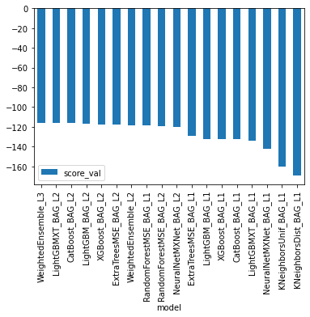

```python
predictor.leaderboard(silent=True).plot(kind="bar", x="model", y="score_val")
```

### Create predictions from test dataset

```python
predictions = predictor.predict(test)
predictions.head()
```

```
0     96.069901
1     90.754486
2     90.754539
3    103.251740
4    103.301376
Name: count, dtype: float32
```

#### NOTE: Kaggle will reject the submission if we don't set everything to be > 0.

```python
# Describe the `predictions` series to see if there are any negative values
predictions.describe()
```

```
count    6493.000000
mean      208.775116
std       126.900215
min        10.557646
25%       105.303009
50%       192.448074
75%       291.096222
max       643.224121
Name: count, dtype: float64
```

```python
# How many negative values do we have?
predictions[predictions<0].count()
```

```
0
```

```python
# Set them to zero
# N/A all values are non-negative
```

### Set predictions to submission dataframe, save, and submit

```python
submission["count"] = predictions
submission.to_csv("submission.csv", index=False)
```

```python
!kaggle competitions submit -c bike-sharing-demand -f submission.csv -m "first raw submission"
```

```
Successfully submitted to Bike Sharing Demand
```

#### View submission via the command line or in the web browser under the competition's page - `My Submissions`

```python
!kaggle competitions submissions -c bike-sharing-demand | tail -n +1 | head -n 6
```

```
fileName        date                 description           status    publicScore  privateScore
--------------  -------------------  --------------------  --------  -----------  ------------
submission.csv  2022-12-29 03:55:03  first raw submission  complete  1.38533      1.38533
```

#### Initial score of 1.38533

## Step 4: Exploratory Data Analysis and Creating an additional feature

- Any additional feature will do, but a great suggestion would be to separate out the datetime into hour, day, or month parts.

```
array([[<AxesSubplot:title={'center':'season'}>,
        <AxesSubplot:title={'center':'holiday'}>,
        <AxesSubplot:title={'center':'workingday'}>],
       [<AxesSubplot:title={'center':'weather'}>,
        <AxesSubplot:title={'center':'temp'}>,
        <AxesSubplot:title={'center':'atemp'}>],
       [<AxesSubplot:title={'center':'humidity'}>,
        <AxesSubplot:title={'center':'windspeed'}>,
        <AxesSubplot:title={'center':'casual'}>],
       [<AxesSubplot:title={'center':'registered'}>,
        <AxesSubplot:title={'center':'count'}>, <AxesSubplot:>]],
      dtype=object)
```

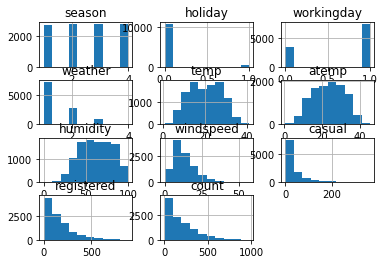

```python
# Create a histogram of all features to show the distribution of each one relative to the data. This is part of the exploritory data analysis
train.hist()
```

```python
# create a new feature
train["day"] = train["datetime"].dt.day
train["month"] = train["datetime"].dt.month
train["year"] = train["datetime"].dt.year
train["hour"] = train["datetime"].dt.hour

test["day"] = test["datetime"].dt.day
test["month"] = test["datetime"].dt.month
test["year"] = test["datetime"].dt.year
test["hour"] = test["datetime"].dt.hour
```

## Make category types for these so models know they are not just numbers

- AutoGluon originally sees these as ints, but in reality they are int representations of a category.
- Setting the dtype to category will classify these as categories in AutoGluon.

```python
train["season"] = train["season"].astype('category')
train["weather"] = train["weather"].astype('category')
test["season"] = test["season"].astype('category')
test["weather"] = test["weather"].astype('category')
```

```python
# View are new feature
train.head()
```

|  | datetime | season | holiday | workingday | weather | temp | atemp | humidity | windspeed | casual | registered | count | day | month | year | hour |
| --- | --- | --- | --- | --- | --- | --- | --- | --- | --- | --- | --- | --- | --- | --- | --- | --- |
| 0 | 2011-01-01 00:00:00 | 1 | 0 | 0 | 1 | 9.84 | 14.395 | 81 | 0.0 | 3 | 13 | 16 | 1 | 1 | 2011 | 0 |
| 1 | 2011-01-01 01:00:00 | 1 | 0 | 0 | 1 | 9.02 | 13.635 | 80 | 0.0 | 8 | 32 | 40 | 1 | 1 | 2011 | 1 |
| 2 | 2011-01-01 02:00:00 | 1 | 0 | 0 | 1 | 9.02 | 13.635 | 80 | 0.0 | 5 | 27 | 32 | 1 | 1 | 2011 | 2 |
| 3 | 2011-01-01 03:00:00 | 1 | 0 | 0 | 1 | 9.84 | 14.395 | 75 | 0.0 | 3 | 10 | 13 | 1 | 1 | 2011 | 3 |
| 4 | 2011-01-01 04:00:00 | 1 | 0 | 0 | 1 | 9.84 | 14.395 | 75 | 0.0 | 0 | 1 | 1 | 1 | 1 | 2011 | 4 |

```
array([[<AxesSubplot:title={'center':'holiday'}>,
        <AxesSubplot:title={'center':'workingday'}>,
        <AxesSubplot:title={'center':'temp'}>,
        <AxesSubplot:title={'center':'atemp'}>],
       [<AxesSubplot:title={'center':'humidity'}>,
        <AxesSubplot:title={'center':'windspeed'}>,
        <AxesSubplot:title={'center':'casual'}>,
        <AxesSubplot:title={'center':'registered'}>],
       [<AxesSubplot:title={'center':'count'}>,
        <AxesSubplot:title={'center':'day'}>,
        <AxesSubplot:title={'center':'month'}>,
        <AxesSubplot:title={'center':'year'}>],
       [<AxesSubplot:title={'center':'hour'}>, <AxesSubplot:>,
        <AxesSubplot:>, <AxesSubplot:>]], dtype=object)
```

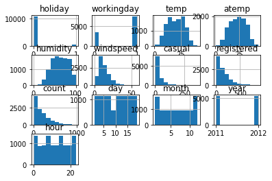

```python
# View histogram of all features again now with the hour feature
train.hist()
```

## Step 5: Rerun the model with the same settings as before, just with more features

```python
predictor_new_features = TabularPredictor(label="count", eval_metric="root_mean_squared_error").fit(
                                                train_data=train.drop(columns=['casual','registered']),
                                                time_limit= 600,
                                                presets="best_quality")
```

```
No path specified. Models will be saved in: "AutogluonModels/ag-20221229_040634/"
Presets specified: ['best_quality']
Beginning AutoGluon training ... Time limit = 600s
AutoGluon will save models to "AutogluonModels/ag-20221229_040634/"
AutoGluon Version:  0.3.1
Train Data Rows:    10886
Train Data Columns: 13
Preprocessing data ...
AutoGluon infers your prediction problem is: 'regression' (because dtype of label-column == int and many unique label-values observed).
	Label info (max, min, mean, stddev): (977, 1, 191.57413, 181.14445)
	If 'regression' is not the correct problem_type, please manually specify the problem_type argument in fit() (You may specify problem_type as one of: ['binary', 'multiclass', 'regression'])
Using Feature Generators to preprocess the data ...
Fitting AutoMLPipelineFeatureGenerator...
	Available Memory:                    1862.8 MB
	Train Data (Original)  Memory Usage: 0.98 MB (0.1% of available memory)
	Inferring data type of each feature based on column values. Set feature_metadata_in to manually specify special dtypes of the features.
	Stage 1 Generators:
		Fitting AsTypeFeatureGenerator...
			Note: Converting 3 features to boolean dtype as they only contain 2 unique values.
	Stage 2 Generators:
		Fitting FillNaFeatureGenerator...
	Stage 3 Generators:
		Fitting IdentityFeatureGenerator...
		Fitting CategoryFeatureGenerator...
			Fitting CategoryMemoryMinimizeFeatureGenerator...
		Fitting DatetimeFeatureGenerator...
	Stage 4 Generators:
		Fitting DropUniqueFeatureGenerator...
	Types of features in original data (raw dtype, special dtypes):
		('category', []) : 2 | ['season', 'weather']
		('datetime', []) : 1 | ['datetime']
		('float', [])    : 3 | ['temp', 'atemp', 'windspeed']
		('int', [])      : 7 | ['holiday', 'workingday', 'humidity', 'day', 'month', ...]
	Types of features in processed data (raw dtype, special dtypes):
		('category', [])             : 2 | ['season', 'weather']
		('float', [])                : 3 | ['temp', 'atemp', 'windspeed']
		('int', [])                  : 4 | ['humidity', 'day', 'month', 'hour']
		('int', ['bool'])            : 3 | ['holiday', 'workingday', 'year']
		('int', ['datetime_as_int']) : 1 | ['datetime']
	0.3s = Fit runtime
	13 features in original data used to generate 13 features in processed data.
	Train Data (Processed) Memory Usage: 0.75 MB (0.0% of available memory)
Data preprocessing and feature engineering runtime = 0.41s ...
AutoGluon will gauge predictive performance using evaluation metric: 'root_mean_squared_error'
	To change this, specify the eval_metric argument of fit()
AutoGluon will fit 2 stack levels (L1 to L2) ...
Fitting 11 L1 models ...
Fitting model: KNeighborsUnif_BAG_L1 ... Training model for up to 399.63s of the 599.58s of remaining time.
	-123.9216	 = Validation score   (root_mean_squared_error)
	0.04s	 = Training   runtime
	0.21s	 = Validation runtime
Fitting model: KNeighborsDist_BAG_L1 ... Training model for up to 399.14s of the 599.1s of remaining time.
	-119.3726	 = Validation score   (root_mean_squared_error)
	0.03s	 = Training   runtime
	0.2s	 = Validation runtime
Fitting model: LightGBMXT_BAG_L1 ... Training model for up to 398.68s of the 598.64s of remaining time.
```

```
[1000]	train_set's rmse: 30.6072	valid_set's rmse: 37.5813
[2000]	train_set's rmse: 25.541	valid_set's rmse: 36.1226
[3000]	train_set's rmse: 22.7223	valid_set's rmse: 35.8367
[4000]	train_set's rmse: 20.7385	valid_set's rmse: 35.7909
```

[output not shown]

```
[1000]	train_set's rmse: 30.6399	valid_set's rmse: 35.4063
[2000]	train_set's rmse: 25.7112	valid_set's rmse: 34.2535
[3000]	train_set's rmse: 22.9824	valid_set's rmse: 34.0723
```

[output not shown]

```
[1000]	train_set's rmse: 30.6885	valid_set's rmse: 38.3533
[2000]	train_set's rmse: 25.5961	valid_set's rmse: 37.1256
[3000]	train_set's rmse: 22.7796	valid_set's rmse: 36.7038
```

```
[1000]	train_set's rmse: 30.1415	valid_set's rmse: 41.208
[2000]	train_set's rmse: 25.1967	valid_set's rmse: 40.3707
[3000]	train_set's rmse: 22.4265	valid_set's rmse: 40.1018
```

```
[1000]	train_set's rmse: 30.7152	valid_set's rmse: 38.8438
[2000]	train_set's rmse: 25.6909	valid_set's rmse: 35.8478
[3000]	train_set's rmse: 22.8713	valid_set's rmse: 34.9997
[4000]	train_set's rmse: 20.9309	valid_set's rmse: 34.6359
[5000]	train_set's rmse: 19.3844	valid_set's rmse: 34.4976
[6000]	train_set's rmse: 18.1646	valid_set's rmse: 34.4135
[7000]	train_set's rmse: 17.1012	valid_set's rmse: 34.3901
[8000]	train_set's rmse: 16.1569	valid_set's rmse: 34.4729
```

[output not shown]

```
[1000]	train_set's rmse: 30.2782	valid_set's rmse: 40.9867
[2000]	train_set's rmse: 25.388	valid_set's rmse: 40.1381
```

[output not shown]

```
	-36.8059	 = Validation score   (root_mean_squared_error)
	89.73s	 = Training   runtime
	6.35s	 = Validation runtime
Fitting model: LightGBM_BAG_L1 ... Training model for up to 290.81s of the 490.76s of remaining time.
```

```
[1000]	train_set's rmse: 21.1363	valid_set's rmse: 35.556
[2000]	train_set's rmse: 15.5229	valid_set's rmse: 35.4489
```

```
[1000]	train_set's rmse: 21.0431	valid_set's rmse: 36.9387
[2000]	train_set's rmse: 15.5393	valid_set's rmse: 36.1222
[3000]	train_set's rmse: 12.2068	valid_set's rmse: 35.9676
[4000]	train_set's rmse: 9.97753	valid_set's rmse: 35.9638
```

```
[1000]	train_set's rmse: 21.4253	valid_set's rmse: 33.0295
```

```
[1000]	train_set's rmse: 21.4591	valid_set's rmse: 38.0987
[2000]	train_set's rmse: 15.6967	valid_set's rmse: 37.1129
[3000]	train_set's rmse: 12.2044	valid_set's rmse: 36.7212
[4000]	train_set's rmse: 9.95476	valid_set's rmse: 36.6786
```

```
[1000]	train_set's rmse: 21.43	valid_set's rmse: 37.371
[2000]	train_set's rmse: 15.5136	valid_set's rmse: 36.986
```

```
[1000]	train_set's rmse: 21.6619	valid_set's rmse: 35.9541
```

```
[1000]	train_set's rmse: 21.0051	valid_set's rmse: 35.6024
[2000]	train_set's rmse: 15.4015	valid_set's rmse: 34.9824
```

```
[1000]	train_set's rmse: 21.3287	valid_set's rmse: 36.3245
[2000]	train_set's rmse: 15.6834	valid_set's rmse: 35.8282
[3000]	train_set's rmse: 12.2992	valid_set's rmse: 35.5694
[4000]	train_set's rmse: 10.1773	valid_set's rmse: 35.5318
```

[output not shown]

[output cut: 141 more lines]

```
	[11]	train_set's rmse: 131.47	valid_set's rmse: 130.376
	Ran out of time, early stopping on iteration 10. Best iteration is:
	[10]	train_set's rmse: 134.423	valid_set's rmse: 143.419
	Ran out of time, early stopping on iteration 11. Best iteration is:
	[11]	train_set's rmse: 131.573	valid_set's rmse: 129.88
	Ran out of time, early stopping on iteration 7. Best iteration is:
	[7]	train_set's rmse: 147.394	valid_set's rmse: 148.548
	Time limit exceeded... Skipping LightGBMLarge_BAG_L2.
Completed 1/20 k-fold bagging repeats ...
Fitting model: WeightedEnsemble_L3 ... Training model for up to 360.0s of the 0.81s of remaining time.
	-35.2543	 = Validation score   (root_mean_squared_error)
	0.43s	 = Training   runtime
	0.0s	 = Validation runtime
AutoGluon training complete, total runtime = 599.82s ...
TabularPredictor saved. To load, use: predictor = TabularPredictor.load("AutogluonModels/ag-20221229_040634/")
```

```python
predictor_new_features.fit_summary()
```

```
*** Summary of fit() ***
Estimated performance of each model:
                     model   score_val  pred_time_val    fit_time  pred_time_val_marginal  fit_time_marginal  stack_level  can_infer  fit_order
0      WeightedEnsemble_L2  -35.166607       8.567561  167.169298                0.000902           0.482287            2       True          9
1      WeightedEnsemble_L3  -35.254268      14.634250  450.141200                0.000920           0.433313            3       True         17
2          CatBoost_BAG_L2  -35.516503      11.585227  337.357012                0.068409          35.598305            2       True         13
3     ExtraTreesMSE_BAG_L2  -35.578407      11.990943  309.212799                0.474125           7.454092            2       True         14
4          LightGBM_BAG_L2  -35.783100      11.628549  308.964927                0.111731           7.206220            2       True         11
5        LightGBMXT_BAG_L2  -36.126122      11.731417  312.245999                0.214598          10.487292            2       True         10
6   RandomForestMSE_BAG_L2  -36.233824      11.987809  328.737985                0.470991          26.979278            2       True         12
7           XGBoost_BAG_L2  -36.292028      11.637995  315.037782                0.121177          13.279075            2       True         15
8          LightGBM_BAG_L1  -36.586276       1.457011   33.275398                1.457011          33.275398            1       True          4
9        LightGBMXT_BAG_L1  -36.805873       6.350356   89.725855                6.350356          89.725855            1       True          3
10          XGBoost_BAG_L1  -37.414256       0.330871   33.009098                0.330871          33.009098            1       True          7
11    ExtraTreesMSE_BAG_L1  -41.092911       0.408003    4.240557                0.408003           4.240557            1       True          6
12  RandomForestMSE_BAG_L1  -41.347171       0.428420   10.676661                0.428420          10.676661            1       True          5
13   NeuralNetMXNet_BAG_L2  -54.361925      13.764466  388.961978                2.247648          87.203271            2       True         16
14   NeuralNetMXNet_BAG_L1 -119.290014       2.127721  130.755767                2.127721         130.755767            1       True          8
15   KNeighborsDist_BAG_L1 -119.372602       0.203823    0.031756                0.203823           0.031756            1       True          2
16   KNeighborsUnif_BAG_L1 -123.921631       0.210612    0.043616                0.210612           0.043616            1       True          1
Number of models trained: 17
Types of models trained:
{'StackerEnsembleModel_XGBoost', 'StackerEnsembleModel_LGB', 'StackerEnsembleModel_KNN', 'StackerEnsembleModel_TabularNeuralNet', 'StackerEnsembleModel_XT', 'StackerEnsembleModel_RF', 'StackerEnsembleModel_CatBoost', 'WeightedEnsembleModel'}
Bagging used: True  (with 10 folds)
Multi-layer stack-ensembling used: True  (with 3 levels)
Feature Metadata (Processed):
(raw dtype, special dtypes):
('category', [])             : 2 | ['season', 'weather']
('float', [])                : 3 | ['temp', 'atemp', 'windspeed']
('int', [])                  : 4 | ['humidity', 'day', 'month', 'hour']
('int', ['bool'])            : 3 | ['holiday', 'workingday', 'year']
('int', ['datetime_as_int']) : 1 | ['datetime']
Plot summary of models saved to file: AutogluonModels/ag-20221229_040634/SummaryOfModels.html
*** End of fit() summary ***
```

[output not shown]

[output cut: 163 more lines]

```
 2          13
 3          14
 4          11
 5          10
 6          12
 7          15
 8           4
 9           3
 10          7
 11          6
 12          5
 13         16
 14          8
 15          2
 16          1  }
```

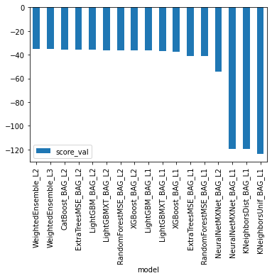

```python
predictor_new_features.leaderboard(silent=True).plot(kind="bar", x="model", y="score_val")
```

```python
predictions_new_features = predictor_new_features.predict(test)
predictions_new_features[predictions_new_features<0].count()
```

```
127
```

```python
# Remember to set all negative values to zero
predictions_new_features[predictions_new_features<0] = 0
predictions_new_features[predictions_new_features<0].count()
```

```
0
```

```python
# Same submitting predictions
submission_new_features = submission
submission_new_features["count"] = predictions_new_features
submission_new_features.to_csv("submission_new_features.csv", index=False)
```

```python
!kaggle competitions submit -c bike-sharing-demand -f submission_new_features.csv -m "new features"
```

```
Successfully submitted to Bike Sharing Demand
```

```python
!kaggle competitions submissions -c bike-sharing-demand | tail -n +1 | head -n 6
```

```
fileName                     date                 description           status    publicScore  privateScore
---------------------------  -------------------  --------------------  --------  -----------  ------------
submission_new_features.csv  2022-12-29 04:27:45  new features          complete  0.55702      0.55702
submission.csv               2022-12-29 03:55:03  first raw submission  complete  1.38533      1.38533
```

#### New Score of 0.55702

## Step 6: Hyper parameter optimization

- There are many options for hyper parameter optimization.
- Options are to change the AutoGluon higher level parameters or the individual model hyperparameters.
- The hyperparameters of the models themselves that are in AutoGluon. Those need the `hyperparameter` and `hyperparameter_tune_kwargs` arguments.

```python
predictor_new_hpo = TabularPredictor(label="count", eval_metric="root_mean_squared_error").fit(
                                                train_data=train.drop(columns=['casual','registered']),
                                                time_limit= 600,
                                                hyperparameters={
                                                    "RF": {},
                                                    "XGB": {},
                                                    "NN": {},
                                                    "CAT": {},
                                                    "GBM": {},
                                                    "XT": {},
                                                },
                                                hyperparameter_tune_kwargs='auto',
                                                presets="best_quality")
```

```
No path specified. Models will be saved in: "AutogluonModels/ag-20221229_045428/"
Presets specified: ['best_quality']
Warning: hyperparameter tuning is currently experimental and may cause the process to hang.
Beginning AutoGluon training ... Time limit = 600s
AutoGluon will save models to "AutogluonModels/ag-20221229_045428/"
AutoGluon Version:  0.3.1
Train Data Rows:    10886
Train Data Columns: 13
Preprocessing data ...
AutoGluon infers your prediction problem is: 'regression' (because dtype of label-column == int and many unique label-values observed).
	Label info (max, min, mean, stddev): (977, 1, 191.57413, 181.14445)
	If 'regression' is not the correct problem_type, please manually specify the problem_type argument in fit() (You may specify problem_type as one of: ['binary', 'multiclass', 'regression'])
Using Feature Generators to preprocess the data ...
Fitting AutoMLPipelineFeatureGenerator...
	Available Memory:                    1306.47 MB
	Train Data (Original)  Memory Usage: 0.98 MB (0.1% of available memory)
	Inferring data type of each feature based on column values. Set feature_metadata_in to manually specify special dtypes of the features.
	Stage 1 Generators:
		Fitting AsTypeFeatureGenerator...
			Note: Converting 3 features to boolean dtype as they only contain 2 unique values.
	Stage 2 Generators:
		Fitting FillNaFeatureGenerator...
	Stage 3 Generators:
		Fitting IdentityFeatureGenerator...
		Fitting CategoryFeatureGenerator...
			Fitting CategoryMemoryMinimizeFeatureGenerator...
		Fitting DatetimeFeatureGenerator...
	Stage 4 Generators:
		Fitting DropUniqueFeatureGenerator...
	Types of features in original data (raw dtype, special dtypes):
		('category', []) : 2 | ['season', 'weather']
		('datetime', []) : 1 | ['datetime']
		('float', [])    : 3 | ['temp', 'atemp', 'windspeed']
		('int', [])      : 7 | ['holiday', 'workingday', 'humidity', 'day', 'month', ...]
	Types of features in processed data (raw dtype, special dtypes):
		('category', [])             : 2 | ['season', 'weather']
		('float', [])                : 3 | ['temp', 'atemp', 'windspeed']
		('int', [])                  : 4 | ['humidity', 'day', 'month', 'hour']
		('int', ['bool'])            : 3 | ['holiday', 'workingday', 'year']
		('int', ['datetime_as_int']) : 1 | ['datetime']
	0.2s = Fit runtime
	13 features in original data used to generate 13 features in processed data.
	Train Data (Processed) Memory Usage: 0.75 MB (0.1% of available memory)
Data preprocessing and feature engineering runtime = 0.35s ...
AutoGluon will gauge predictive performance using evaluation metric: 'root_mean_squared_error'
	To change this, specify the eval_metric argument of fit()
AutoGluon will fit 2 stack levels (L1 to L2) ...
Fitting 6 L1 models ...
Hyperparameter tuning model: LightGBM_BAG_L1 ...
```

```
[1000]	train_set's rmse: 21.1363	valid_set's rmse: 35.556
[2000]	train_set's rmse: 15.5229	valid_set's rmse: 35.4489
```

```
	Time limit exceeded
Fitted model: LightGBM_BAG_L1/T0 ...
	-35.3517	 = Validation score   (root_mean_squared_error)
	2.94s	 = Training   runtime
	0.14s	 = Validation runtime
Hyperparameter tuning model: RandomForest_BAG_L1 ...
Fitted model: RandomForest_BAG_L1/T0 ...
	-41.3472	 = Validation score   (root_mean_squared_error)
	10.05s	 = Training   runtime
	0.43s	 = Validation runtime
Hyperparameter tuning model: CatBoost_BAG_L1 ...
	Time limit exceeded
Fitted model: CatBoost_BAG_L1/T0 ...
	-40.4621	 = Validation score   (root_mean_squared_error)
	3.47s	 = Training   runtime
	0.01s	 = Validation runtime
Hyperparameter tuning model: ExtraTrees_BAG_L1 ...
Fitted model: ExtraTrees_BAG_L1/T0 ...
	-41.0929	 = Validation score   (root_mean_squared_error)
	4.23s	 = Training   runtime
	0.43s	 = Validation runtime
Hyperparameter tuning model: XGBoost_BAG_L1 ...
	Time limit exceeded
Fitted model: XGBoost_BAG_L1/T0 ...
	-36.136	 = Validation score   (root_mean_squared_error)
	3.69s	 = Training   runtime
	0.04s	 = Validation runtime
Hyperparameter tuning model: NeuralNetMXNet_BAG_L1 ...
	Ran out of time, stopping training early. (Stopping on epoch 2)
	Time limit exceeded
Fitted model: NeuralNetMXNet_BAG_L1/T0 ...
	-231.2287	 = Validation score   (root_mean_squared_error)
	3.25s	 = Training   runtime
	0.07s	 = Validation runtime
Fitting model: LightGBM_BAG_L1/T0 ... Training model for up to 352.13s of the 552.11s of remaining time.
```

```
[1000]	train_set's rmse: 21.0431	valid_set's rmse: 36.9387
[2000]	train_set's rmse: 15.5393	valid_set's rmse: 36.1222
[3000]	train_set's rmse: 12.2068	valid_set's rmse: 35.9676
[4000]	train_set's rmse: 9.97753	valid_set's rmse: 35.9638
```

```
[1000]	train_set's rmse: 21.4253	valid_set's rmse: 33.0295
```

```
[1000]	train_set's rmse: 21.4591	valid_set's rmse: 38.0987
[2000]	train_set's rmse: 15.6967	valid_set's rmse: 37.1129
[3000]	train_set's rmse: 12.2044	valid_set's rmse: 36.7212
[4000]	train_set's rmse: 9.95476	valid_set's rmse: 36.6786
```

```
[1000]	train_set's rmse: 21.43	valid_set's rmse: 37.371
[2000]	train_set's rmse: 15.5136	valid_set's rmse: 36.986
```

```
[1000]	train_set's rmse: 21.6619	valid_set's rmse: 35.9541
```

```
[1000]	train_set's rmse: 21.0051	valid_set's rmse: 35.6024
[2000]	train_set's rmse: 15.4015	valid_set's rmse: 34.9824
```

```
[1000]	train_set's rmse: 21.3287	valid_set's rmse: 36.3245
[2000]	train_set's rmse: 15.6834	valid_set's rmse: 35.8282
[3000]	train_set's rmse: 12.2992	valid_set's rmse: 35.5694
[4000]	train_set's rmse: 10.1773	valid_set's rmse: 35.5318
```

```
	-36.5863	 = Validation score   (root_mean_squared_error)
	33.87s	 = Training   runtime
	1.61s	 = Validation runtime
Fitting model: RandomForest_BAG_L1/T0 ... Training model for up to 315.9s of the 515.88s of remaining time.
	-41.3472	 = Validation score   (root_mean_squared_error)
	10.05s	 = Training   runtime
	0.43s	 = Validation runtime
Fitting model: CatBoost_BAG_L1/T0 ... Training model for up to 315.83s of the 515.81s of remaining time.
	-37.2345	 = Validation score   (root_mean_squared_error)
	269.42s	 = Training   runtime
	0.13s	 = Validation runtime
Fitting model: ExtraTrees_BAG_L1/T0 ... Training model for up to 48.86s of the 248.85s of remaining time.
	-41.0929	 = Validation score   (root_mean_squared_error)
	4.23s	 = Training   runtime
	0.43s	 = Validation runtime
Fitting model: XGBoost_BAG_L1/T0 ... Training model for up to 48.82s of the 248.8s of remaining time.
	-37.4076	 = Validation score   (root_mean_squared_error)
	33.22s	 = Training   runtime
	0.35s	 = Validation runtime
Fitting model: NeuralNetMXNet_BAG_L1/T0 ... Training model for up to 16.16s of the 216.14s of remaining time.
	Ran out of time, stopping training early. (Stopping on epoch 0)
	Time limit exceeded... Skipping NeuralNetMXNet_BAG_L1/T0.
Completed 1/20 k-fold bagging repeats ...
Fitting model: WeightedEnsemble_L2 ... Training model for up to 360.0s of the 214.08s of remaining time.
	-35.531	 = Validation score   (root_mean_squared_error)
	0.34s	 = Training   runtime
	0.0s	 = Validation runtime
Fitting 6 L2 models ...
Hyperparameter tuning model: LightGBM_BAG_L2 ...
	Ran out of time, early stopping on iteration 223. Best iteration is:
	[223]	train_set's rmse: 30.7515	valid_set's rmse: 39.165
	Time limit exceeded
Fitted model: LightGBM_BAG_L2/T0 ...
	-38.2978	 = Validation score   (root_mean_squared_error)
	0.58s	 = Training   runtime
	0.01s	 = Validation runtime
Fitted model: LightGBM_BAG_L2/T1 ...
	-38.2968	 = Validation score   (root_mean_squared_error)
	0.8s	 = Training   runtime
	0.01s	 = Validation runtime
```

[output cut: 76 more lines]

```
	Ran out of time, stopping training early. (Stopping on epoch 9)
	Ran out of time, stopping training early. (Stopping on epoch 9)
	Ran out of time, stopping training early. (Stopping on epoch 10)
	Ran out of time, stopping training early. (Stopping on epoch 12)
	Ran out of time, stopping training early. (Stopping on epoch 13)
	-74.1456	 = Validation score   (root_mean_squared_error)
	99.21s	 = Training   runtime
	2.14s	 = Validation runtime
Completed 1/20 k-fold bagging repeats ...
Fitting model: WeightedEnsemble_L3 ... Training model for up to 360.0s of the 4.32s of remaining time.
	-35.723	 = Validation score   (root_mean_squared_error)
	0.53s	 = Training   runtime
	0.0s	 = Validation runtime
AutoGluon training complete, total runtime = 596.41s ...
TabularPredictor saved. To load, use: predictor = TabularPredictor.load("AutogluonModels/ag-20221229_045428/")
```

```python
predictor_new_hpo.fit_summary()
```

```
*** Summary of fit() ***
Estimated performance of each model:
                       model   score_val  pred_time_val    fit_time  pred_time_val_marginal  fit_time_marginal  stack_level  can_infer  fit_order
0        WeightedEnsemble_L2  -35.530993       2.522425  346.893765                0.000923           0.340380            2       True          7
1        WeightedEnsemble_L3  -35.722998       6.165542  525.113226                0.001020           0.533576            3       True         17
2         CatBoost_BAG_L2/T0  -35.913663       3.021529  378.102314                0.069052          27.318201            2       True         12
3         LightGBM_BAG_L2/T1  -36.278180       3.071619  357.114556                0.119141           6.330443            2       True          9
4         LightGBM_BAG_L2/T0  -36.278285       3.059138  356.864333                0.106661           6.080219            2       True          8
5         LightGBM_BAG_L2/T2  -36.370781       3.074305  357.252910                0.121827           6.468796            2       True         10
6       ExtraTrees_BAG_L2/T0  -36.390721       3.107259  352.944816                0.154782           2.160702            2       True         13
7          XGBoost_BAG_L2/T1  -36.552772       3.077407  360.359658                0.124930           9.575544            2       True         15
8         LightGBM_BAG_L1/T0  -36.586276       1.609510   33.865869                1.609510          33.865869            1       True          1
9          XGBoost_BAG_L2/T0  -36.695797       3.076086  360.493721                0.123608           9.709608            2       True         14
10    RandomForest_BAG_L2/T0  -36.727100       3.430894  373.512375                0.478417          22.728261            2       True         11
11        CatBoost_BAG_L1/T0  -37.234542       0.134847  269.422828                0.134847         269.422828            1       True          3
12         XGBoost_BAG_L1/T0  -37.407574       0.346947   33.218084                0.346947          33.218084            1       True          5
13      ExtraTrees_BAG_L1/T0  -41.092911       0.430975    4.230728                0.430975           4.230728            1       True          4
14    RandomForest_BAG_L1/T0  -41.347171       0.430198   10.046604                0.430198          10.046604            1       True          2
15  NeuralNetMXNet_BAG_L2/T0  -74.145606       5.096375  449.997704                2.143897          99.213590            2       True         16
16  NeuralNetMXNet_BAG_L1/T0 -231.228653       0.066689    3.252340                0.066689           3.252340            1       True          6
Number of models trained: 17
Types of models trained:
{'StackerEnsembleModel_XGBoost', 'StackerEnsembleModel_LGB', 'StackerEnsembleModel_TabularNeuralNet', 'StackerEnsembleModel_XT', 'StackerEnsembleModel_RF', 'StackerEnsembleModel_CatBoost', 'WeightedEnsembleModel'}
Bagging used: True  (with 10 folds)
Multi-layer stack-ensembling used: True  (with 3 levels)
Feature Metadata (Processed):
(raw dtype, special dtypes):
('category', [])             : 2 | ['season', 'weather']
('float', [])                : 3 | ['temp', 'atemp', 'windspeed']
('int', [])                  : 4 | ['humidity', 'day', 'month', 'hour']
('int', ['bool'])            : 3 | ['holiday', 'workingday', 'year']
('int', ['datetime_as_int']) : 1 | ['datetime']
Plot summary of models saved to file: AutogluonModels/ag-20221229_045428/SummaryOfModels.html
*** End of fit() summary ***
```

[output not shown]

[output cut: 161 more lines]

```
 2          12
 3           9
 4           8
 5          10
 6          13
 7          15
 8           1
 9          14
 10         11
 11          3
 12          5
 13          4
 14          2
 15         16
 16          6  }
```

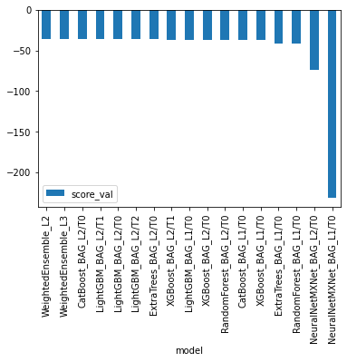

```python
predictor_new_hpo.leaderboard(silent=True).plot(kind="bar", x="model", y="score_val")
```

```python
predictions_new_hpo = predictor_new_hpo.predict(test)
predictions_new_hpo[predictions_new_hpo<0].count()
```

```
123
```

```python
# Remember to set all negative values to zero
predictions_new_hpo[predictions_new_hpo<0] = 0
predictions_new_hpo[predictions_new_hpo<0].count()
```

```
0
```

```python
# Same submitting predictions
submission_new_hpo = submission
submission_new_hpo["count"] = predictions_new_hpo
submission_new_hpo.to_csv("submission_new_hpo.csv", index=False)
```

```python
!kaggle competitions submit -c bike-sharing-demand -f submission_new_hpo.csv -m "new features with hyperparameters"
```

```
Successfully submitted to Bike Sharing Demand
```

```python
!kaggle competitions submissions -c bike-sharing-demand | tail -n +1 | head -n 6
```

```
fileName                     date                 description                        status    publicScore  privateScore
---------------------------  -------------------  ---------------------------------  --------  -----------  ------------
submission_new_hpo.csv       2022-12-29 05:07:16  new features with hyperparameters  complete  0.55230      0.55230
submission_new_hpo.csv       2022-12-29 04:53:02  new features with hyperparameters  complete  0.55874      0.55874
submission_new_features.csv  2022-12-29 04:27:45  new features                       complete  0.55702      0.55702
submission.csv               2022-12-29 03:55:03  first raw submission               complete  1.38533      1.38533
```

#### New Score of 0.55230

## Step 7: Write a Report

### Refer to the markdown file for the full report

### Creating plots and table for report

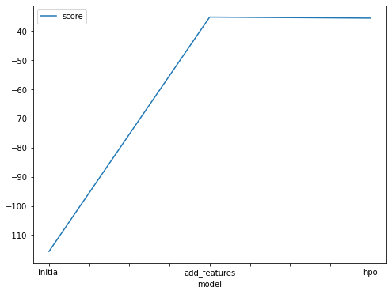

```python
# Taking the top model score from each training run and creating a line plot to show improvement
# You can create these in the notebook and save them to PNG or use some other tool (e.g. google sheets, excel)
fig = pd.DataFrame(
    {
        "model": ["initial", "add_features", "hpo"],
        "score": [-115.596863, -35.166607, -35.530993]
    }
).plot(x="model", y="score", figsize=(8, 6)).get_figure()
fig.savefig('model_train_score.png')
```

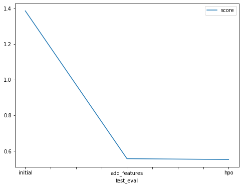

```python
# Take the 3 kaggle scores and creating a line plot to show improvement
fig = pd.DataFrame(
    {
        "test_eval": ["initial", "add_features", "hpo"],
        "score": [1.38533, 0.55702, 0.55230]
    }
).plot(x="test_eval", y="score", figsize=(8, 6)).get_figure()
fig.savefig('model_test_score.png')
```

### Hyperparameter table

```python
# The 3 hyperparameters we tuned with the kaggle score as the result
pd.DataFrame({
    "model": ["initial", "add_features", "hpo"],
    "hpo1 (presets)": ["best_quality", "best_quality", "best_quality"],
    "hpo2 (time_limit)": [600, 600, 600],
    "hpo3 (models)": ["default", "default",   "RF,XGB, NN, CAT, GBM, XT"],
    "score": [1.38533, 0.55702, 0.55230]
})
```

|  | model | hpo1 (presets) | hpo2 (time_limit) | hpo3 (models) | score |
| --- | --- | --- | --- | --- | --- |
| 0 | initial | best_quality | 600 | default | 1.38533 |
| 1 | add_features | best_quality | 600 | default | 0.55702 |
| 2 | hpo | best_quality | 600 | RF,XGB, NN, CAT, GBM, XT | 0.55230 |